# Recursos regionalizados para el procesamiento automático de datos de redes sociales

MexLEF, Puebla, México

[Eric S. Téllez](https://sadit.github.io)

INFOTEC

[Mario Graff](https://mgraffg.github.io)

INFOTEC

[Daniela Moctezuma](https://dmocteo.github.io/)

CentroGEO

Sabino Miranda-Jiménez

UACM

Guillermo Ruiz

INFOTEC

2023-10-01

## Sobre esta charla

Tellez, E. S., Moctezuma, D., Miranda, S., Graff, M., & Ruiz, G. (2023). Regionalized models for Spanish language variations based on Twitter. Language Resources and Evaluation, 1-31.

```
@article{regionalized2023,
  title={Regionalized models for Spanish language variations based on Twitter},
  author={Tellez, Eric S and Moctezuma, Daniela and Miranda, Sabino and Graff, Mario and Ruiz, Guillermo},
  journal={Language Resources and Evaluation},
  pages={1--31},
  year={2023},
  publisher={Springer}
}
```

- [ArXiv](https://arxiv.org/abs/2110.06128) preprint.

## Aplicaciones de Procesamiento de Lenguaje Natural (1/2)

- **Minería de opinión**
  - positivo :) — neutro :| — negativo :(
- **Análisis de tópicos**
- **Carga emotiva de un mensaje**: *enojo, anticipación, disgusto, miedo, gozo, tristeza, sorpresa, confianza*.
- **Identificación de humor**
- **Identificación de lenguaje de odio**
- Etc.

## Aplicaciones de Procesamiento de Lenguaje Natural (2/2)

- **Predicción indicadores socio-demográficos de usuarios de redes**, e.g., edad, sexo, lugar de procedencia, ocupación
- **Identificación de autoría**: ¿quiénes escriben?, ¿cómo escriben?, ¿sobre qué escriben?
- **Entender como se comportan usuarios**, ¿qué desean?, ¿por qué?
- **Medición de discurso de odio en redes sociales**, e.g., xenofobia, racismo, misoginia, cyberbulling.
- **Identificación de posibles trastornos mentales**, e.g., ansiedad, depresión, adicciones.
- **Aplicaciones** a seguridad, salud, políticas públicas, economía y finanzas.

## Algunos retos

- Escritos informales: muchos errores, onomatopeya, importación de términos, variaciones regionales, emojis, entre muchos otros.
- Contextos cortos, conocimiento del mundo.
- Negación, sarcasmo, ironía, humor.
- Semántica.
- Recursos lingüísticos reducidos para lenguajes diferentes del inglés.
- Multimedios.

## Regionalización

Todo lo anterior puede regionalizarse, ya que un mismo lenguaje puede usarse de manera diferente en diferentes regiones.

Para tareas dónde haya una fuerte carga cultural o de idiosincrasia el uso de recursos regionalizados es provechoso.

## Regionalización como herramienta

Entender las **variaciones del lenguaje** en las redes sociales es primordial ya que los mensajes suelen ser **informales**, y es común que los usuarios solo quieran ser leídos por su *círculo* de personas cercanas.

# ¿Cómo se ven los mensajes en diferentes regiones?

## España 🇪🇸

- me dais ascooooikiiikioooooooooooooooooooooooooo
- kina ñefla
- ns cmo s exribe
- o indeciso, nse ya x dnde cogerte colega
- q os follennjajabya quisieran
- en el metro q voy esta potando uno
- _USR 😂😭💔☹️😰 pero por qué churra

## Argentina 🇦🇷

- pofr suerxte m8ís amigo mo son psicópatassa
- pal pinnngooo
- _USR estos rompen todo! y la esposa del chorro me tiró en la cara q era planera, 5 hijos tiene. me grita: vos seguí alquilando! decí q no la agarro de los pelos x mi hijo q no le gusta el bardo.
- y dsp se comió un asado, moooy booeno👌👌🤣😂
- mi hno se pone re denso no lo banco

## México 🇲🇽

- _USR ahora si! #achingarasumadre nefasto, corrupto y ratero, por mucho eres el peor alcalde que ha tenido _USR
- ya me ando echando la primera ca** del año
- _USR acá ya andaban con “la chica que soñé”
- _USR ¿no se te olvidó ponerte calzones rojos hoy, verdad?
- un minuto de silencio por los que se estan reventando los dedos y las manos con los cohetes !!!

# El corpus

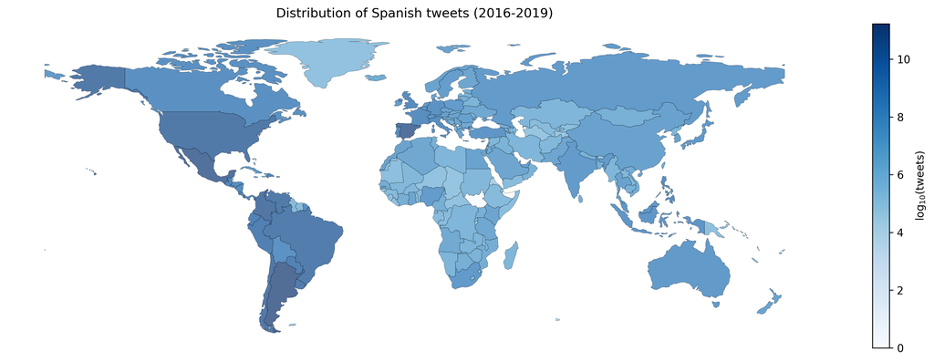

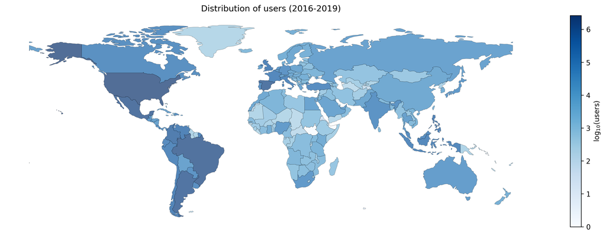

Twitter corpora

| country | code | #users | #tweets | #tokens |
| --- | --- | --- | --- | --- |
| Argentina | AR | 1,376K | 234.22M | 2,887.92M |
| Bolivia | BO | 36K | 1.15M | 20.99M |
| Chile | CL | 415K | 45.29M | 719.24M |
| Colombia | CO | 701K | 61.54M | 918.51M |
| Costa Rica | CR | 79K | 7.51M | 101.67M |
| Cuba | CU | 32K | 0.37M | 6.30M |
| Dominican Republic | DO | 112K | 7.65M | 122.06M |
| Ecuador | EC | 207K | 13.76M | 226.03M |
| El Salvador | SV | 49K | 2.71M | 44.46M |
| Equatorial Guinea | GQ | 1K | 8.93K | 0.14M |
| Guatemala | GT | 74K | 5.22M | 75.79M |
| Honduras | HN | 35K | 2.14M | 31.26M |
| Mexico | MX | 1,517K | 115.53M | 1,635.69M |

| country | code | #users | #tweets | #tokens |
| --- | --- | --- | --- | --- |
| Nicaragua | NI | 35K | 3.34M | 42.47M |
| Panama | PA | 83K | 6.62M | 108.74M |
| Paraguay | PY | 106K | 10.28M | 141.75M |
| Peru | PE | 271K | 15.38M | 241.60M |
| Puerto Rico | PR | 18K | 0.58M | 7.64M |
| Spain | ES | 1,278K | 121.42M | 1,908.07M |
| Uruguay | UY | 157K | 30.83M | 351.81M |
| Venezuela | VE | 421K | 35.48M | 556.12M |
| - | - | - | - | - |
| Brazil | BR | 1,604K | 27.20M | 142.22M |
| Canada | CA | 149K | 1.55M | 21.58M |
| France | FR | 292K | 2.43M | 27.73M |
| Great Britain | GB | 380K | 2.68M | 34.62M |
| United States of America | US | 2,652K | 40.83M | 501.86M |
| **Total** |  | 12M | 795.74M | 10,876.25M |

Se colectaron mensajes georeferenciados de 2016 a 2019 usando el API de *stream* público de Twitter.

# Recursos

- Vocabularios
- Word embeddings
- Modelos de lenguaje

# Recursos léxicos

## Vocabularios

| token | occs | ndocs | weight | n_regions | country_codes |
| --- | --- | --- | --- | --- | --- |
| chau | 409,398 | 387,910 | 10.001527 | 25 | AR:BO:BR:CA:CL:CO:CR:CU:DO:EC:ES:FR:GB:GT:HN:MX:NI:PA:PE:PR:PY:SV:US:UY:VE |
| siento | 2,830,971 | 2,764,088 | 7.168519 | 26 | AR:BO:BR:CA:CL:CO:CR:CU:DO:EC:ES:FR:GB:GQ:GT:HN:MX:NI:PA:PE:PR:PY:SV:US:UY:VE |
| adios | 341,841 | 327,723 | 10.244771 | 25 | AR:BO:BR:CA:CL:CO:CR:CU:DO:EC:ES:FR:GB:GT:HN:MX:NI:PA:PE:PR:PY:SV:US:UY:VE |
| personas | 3,720,458 | 3,620,029 | 6.779321 | 26 | AR:BO:BR:CA:CL:CO:CR:CU:DO:EC:ES:FR:GB:GQ:GT:HN:MX:NI:PA:PE:PR:PY:SV:US:UY:VE |
| huevo | 540,941 | 527,792 | 9.55728 | 25 | AR:BO:BR:CA:CL:CO:CR:CU:DO:EC:ES:FR:GB:GT:HN:MX:NI:PA:PE:PR:PY:SV:US:UY:VE |
| … | … | … | … | … | … |

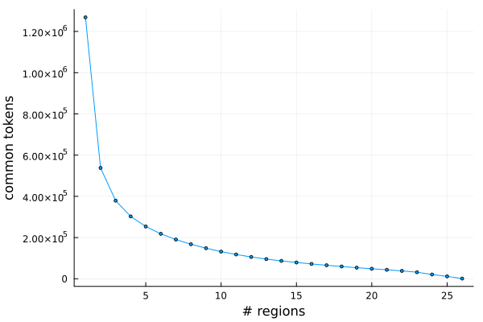

## Propiedades de los vocabularios (1/2)

### Ley de Zipf

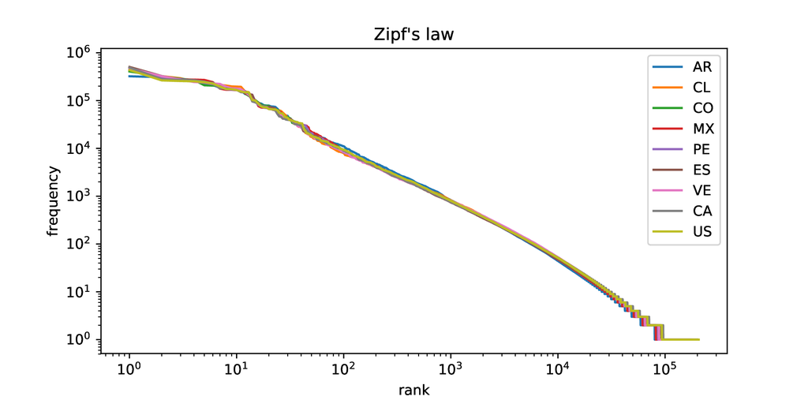

Ley de Zipf para diferentes regiones (Twitter)

## Propiedades de los vocabularios (2/2)

### Ley de Heaps

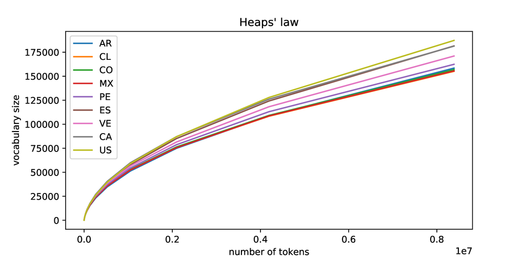

Ley de Heaps para diferentes regiones (Twitter)

## Similitud léxica entre regiones (1/2)

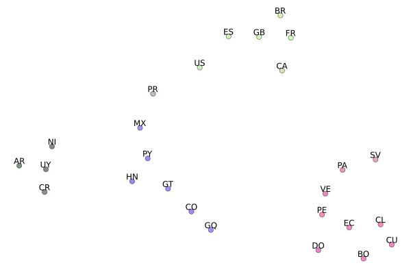

## Similitud léxica entre regiones (2/2)

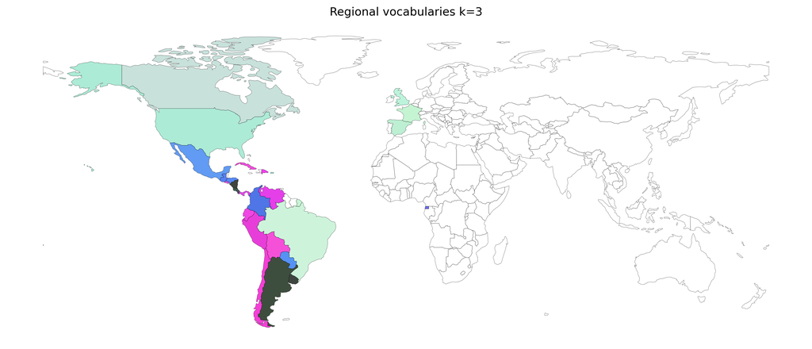

# Word embeddings (recursos semánticos)

Creados con fastText sobre nuestra corpora regionalizada de Twitter. Disponibles desde el **sitio** del proyecto en diferentes dimensiones, e.g, 300, 32, 16 y 8 dimensiones.

Modelos para las 27 regiones (26 países + un modelo aglutinado)

## Similitud entre regiones

Necesitamos una matriz de afinidad, como lo hicimos con el caso léxico, pero **los embeddings de diferentes regiones no son comparables entre sí.**

Para calcular la similitud usamos una representación que extrae información semántica basada en el grafo de los $k$ vecinos cercanos. Esto soluciona el problema de comparación, pero aumenta los requerimientos de computo.

## Notas para el modelado de regiones con word embeddings

- Recordando, cada palabra es un punto en $300$ dimensiones.
- La distancia entre puntos se mide usando $1 - cos(u, v)$.
- Cada región es una nube de puntos (palabras).
- Uso de un vocabulario restringuido (preservar tokens que aparecen en al menos 10 regiones); esto también reduce el problema de la disparidad de datos entre diferentes corpus.
- Uso de herramientas especiales para la construcción de la gráfica de $k$ vecinos ($k=33$).
- Cada región se representa en un vector disperso de muy alta dimensión, i.e., $10^{10}$ componentes con $\approx{}3.8$ millones de componentes diferentes de zero. Se mide nuevamente con distancia coseno, pero con los vectores resultantes.

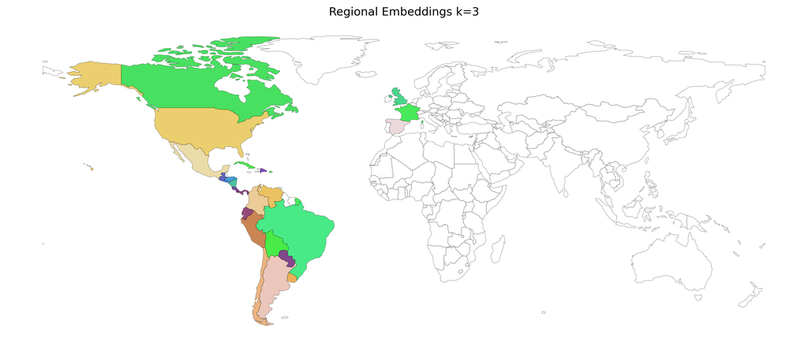

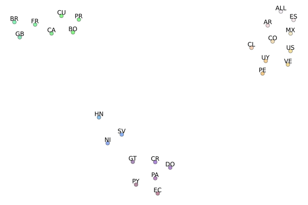

## Ejemplos de $k$ vecinos (*violencia*)

| AR | CL | CO | ES | MX | US | VE |
| --- | --- | --- | --- | --- | --- | --- |
| violencias | violencias | violencias | violencias | violencias | violencias | violencias |
| agresion | vandalismo | violentos | violente | feminicidios | violenten | violentos |
| denigracion | agresion | estigmatizacion | intrafamiliar | femicidios | violente | violenten |
| agresiones | represion | violente | represion | violentas | violentos | violente |
| verbal | bandalismo | intrafamiliar | violenten | vandalismo | violentas | violenta |
| violecia | agresiones | violenten | violecia | femicidio | violentar | confrontacion |
| discriminacion | violenten | bandalismo | violentos | violente | violentan | violentas |
| violentos | violente | agresiones | violentas | bandalismo | delincuencia | terrorismo |
| misoginia | vandalismos | violentas | violenta | feminicidio | violentada | intolerancia |
| vandalismo | violentos | represion | violentar | agresion | violenta | violecia |
| revictimizacion | violenta | vandalismo | terrorismo | intrafamiliar | feminicidios | vandalismos |
| amedrentamiento | violentas | intolerancia | criminalizacion | asesinatos | violentado | represion |
| genero | incitacion | incitacion | violentada | agresiones | vandalismo | confrontaciones |
| intolerancia | intrafamiliar | intimidacion | agresiones | delincuencia | violentando | vandalismo |

## Ejemplos de $k$ vecinos (*chile*)

| AR | CL | CO | ES | MX | US | VE |
| --- | --- | --- | --- | --- | --- | --- |
| ecuador | chiles | uruguay | chile0 | chile0 | chilen | argentina |
| peru | chilee | argentina | argentina | chilee | chilee | peru |
| chile0 | chilito | peru | paraguay | piquin | chilenos | ecuador |
| uruguay | pais | bolivia | mexico | chilito | chile0 | chile0 |
| mexico | latinoamerica | chilen | uruguay | chilensis | chileno | chiles |
| chilen | chile0 | ecuador | peru | habanero | chilena | paraguay |
| brasil | chil | paraguay | bolivia | morron | uchile | chilena |
| bolivia | america0 | brasil | colombia | uchile | shile | bolivia |
| colombia | 🇨 | chilenos | brasil | chiles | chilito | uruguay |
| paraguay | suramerica | mexico | chilenos | verdolagas | chilenito | brasil |
| chiles | sudamerica | chiles | chilen | jalapeno | argentina | chilen |
| chilee | 🇱 | honduras | ecuador | pimiento | chilenas | chilenos |
| rusia | argentina | chile0 | chileno | chil | chiles | chilensis |

## UMAP projection (MX)

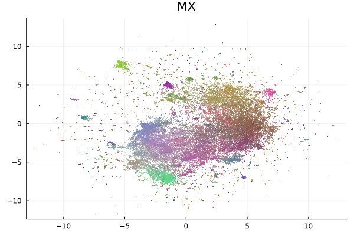

## UMAP projection (ALL)

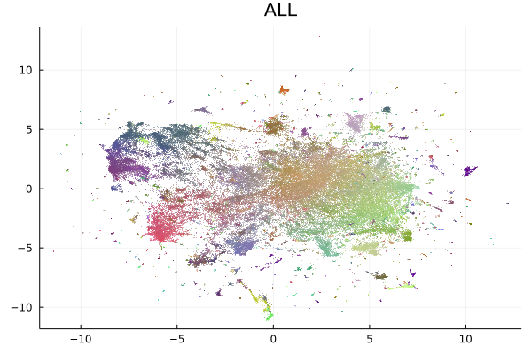

# Emoji-15: predicción de emojis, ejemplo de clasificación regional

Predicción emojis que podrían estar asociados a un mensaje

- Tomamos mensajes georeferenciados enero-febrero 2020.
- Seleccionamos los emoji objetivos entre los más populares en español: 🥺, ❤, 👌, 👏, 💔, 😄, 😊, 😌, 😍, 😒, 😘, 😡, 😢, 😭, 🤔.
- Para cada región seleccionamos mensajes con solo uno de estos emoji.
- El emoji en cuestión se reemplaza por la cadena `_emo` y se usa como etiqueta.
- Partición 50-50 por cada región, se reporta micro recall.
- Usamos fastText supevisado con cada uno de los modelos regionales como preentrenados – all vs all.

| emoji | AR | BR | CA | CL | CO | CR | CU | DO | EC | ES | FR | GB | GT | HN | MX | NI | PA | PE | PY | SV | US | UY | VE |
| --- | --- | --- | --- | --- | --- | --- | --- | --- | --- | --- | --- | --- | --- | --- | --- | --- | --- | --- | --- | --- | --- | --- | --- |
| 🥺 | 3749 | 275 | 158 | 1263 | 4760 | 425 | 26 | 458 | 745 | 2640 | 53 | 95 | 666 | 708 | 10160 | 736 | 827 | 739 | 684 | 278 | 2536 | 446 | 359 |
| ❤ | 18454 | 1775 | 124 | 2911 | 6237 | 821 | 41 | 348 | 1123 | 8394 | 153 | 255 | 653 | 609 | 9508 | 491 | 880 | 968 | 1800 | 219 | 3216 | 1478 | 784 |
| 👌 | 2114 | 92 | 34 | 1016 | 1455 | 242 | 20 | 167 | 253 | 1825 | 41 | 58 | 376 | 157 | 2754 | 159 | 313 | 160 | 666 | 124 | 597 | 190 | 71 |
| 👏 | 6785 | 433 | 80 | 2995 | 2486 | 159 | 33 | 369 | 886 | 7061 | 64 | 105 | 197 | 159 | 4175 | 52 | 388 | 577 | 761 | 222 | 1281 | 1248 | 530 |
| 💔 | 4278 | 100 | 28 | 390 | 1407 | 161 | 7 | 123 | 200 | 1164 | 26 | 37 | 134 | 91 | 1438 | 105 | 260 | 115 | 428 | 31 | 667 | 283 | 142 |
| 😄 | 798 | 26 | 8 | 301 | 300 | 42 | 3 | 56 | 83 | 776 | 4 | 18 | 48 | 48 | 549 | 17 | 58 | 115 | 92 | 53 | 192 | 85 | 120 |
| 😊 | 3609 | 105 | 35 | 1803 | 1475 | 171 | 32 | 175 | 364 | 3827 | 74 | 56 | 257 | 129 | 3395 | 115 | 236 | 817 | 369 | 192 | 829 | 377 | 293 |
| 😌 | 1184 | 70 | 30 | 827 | 986 | 132 | 44 | 280 | 238 | 1017 | 23 | 23 | 123 | 163 | 2011 | 151 | 293 | 248 | 377 | 78 | 608 | 167 | 110 |
| 😍 | 15999 | 932 | 111 | 2190 | 6824 | 510 | 28 | 509 | 837 | 8000 | 107 | 136 | 491 | 514 | 8711 | 341 | 1010 | 999 | 1996 | 268 | 2232 | 1194 | 686 |
| 😒 | 3081 | 89 | 24 | 920 | 1718 | 155 | 50 | 316 | 291 | 780 | 18 | 22 | 163 | 124 | 2185 | 175 | 322 | 213 | 259 | 127 | 738 | 359 | 236 |
| 😘 | 5935 | 211 | 70 | 1764 | 1482 | 98 | 29 | 119 | 347 | 10785 | 203 | 99 | 171 | 72 | 4290 | 63 | 136 | 374 | 190 | 181 | 1808 | 719 | 493 |
| 😡 | 2777 | 136 | 60 | 1098 | 1412 | 150 | 5 | 110 | 291 | 1320 | 12 | 25 | 158 | 52 | 2428 | 59 | 155 | 227 | 250 | 90 | 769 | 301 | 252 |
| 😢 | 2144 | 89 | 38 | 699 | 1039 | 153 | 8 | 102 | 296 | 1507 | 31 | 39 | 151 | 129 | 2646 | 131 | 204 | 271 | 239 | 69 | 781 | 227 | 135 |
| 😭 | 13873 | 436 | 125 | 1967 | 4461 | 581 | 25 | 604 | 787 | 3935 | 157 | 135 | 388 | 364 | 6752 | 321 | 1057 | 979 | 1832 | 200 | 2799 | 939 | 530 |
| 🤔 | 6751 | 275 | 154 | 2756 | 4173 | 440 | 47 | 614 | 771 | 4781 | 99 | 111 | 421 | 339 | 7380 | 211 | 741 | 1135 | 937 | 384 | 1941 | 951 | 734 |

## Resultados experimentales

| cc | minrecall | maxrecall | localrank | top5 |
| --- | --- | --- | --- | --- |
| AR | 0.4777 | 0.49 | 3 | UY,PY,AR,PE,CO |
| BR | 0.4611 | 0.4879 | 1 | BR,ALL,DO,PY,CR |
| CA | 0.2934 | 0.3533 | 18 | CL,ALL,CO,MX,US |
| CL | 0.4257 | 0.4494 | 1 | CL,US,MX,AR,ES |
| CO | 0.4247 | 0.4365 | 2 | US,CO,VE,EC,GT |
| CR | 0.3689 | 0.388 | 9 | US,VE,ALL,MX,CO |
| DO | 0.3383 | 0.3813 | 13 | US,CO,VE,CL,ALL |
| EC | 0.3797 | 0.4138 | 9 | MX,US,CL,ALL,CO |
| ES | 0.4754 | 0.4855 | 1 | ES,AR,MX,US,VE |
| FR | 0.4187 | 0.4424 | 4 | ALL,GT,EC,FR,PA |

| cc | minrecall | maxrecall | localrank | top5 |
| --- | --- | --- | --- | --- |
| GB | 0.3467 | 0.3756 | 23 | ALL,AR,ES,VE,MX |
| GT | 0.3489 | 0.3882 | 13 | MX,US,ALL,CO,ES |
| HN | 0.3354 | 0.3671 | 18 | PE,EC,BR,CR,UY |
| MX | 0.4233 | 0.4335 | 1 | MX,GT,CR,US,CO |
| NI | 0.3372 | 0.3718 | 18 | VE,CO,CL,MX,US |
| PA | 0.3658 | 0.3927 | 10 | US,CL,VE,CO,PE |
| PE | 0.3799 | 0.4196 | 9 | MX,ALL,US,AR,CO |
| PY | 0.4244 | 0.4417 | 1 | PY,US,BR,PE,UY |
| SV | 0.3226 | 0.3954 | 18 | US,CO,MX,CL,VE |
| US | 0.4041 | 0.4244 | 1 | US,MX,CO,ES,CL |
| UY | 0.4351 | 0.4572 | 1 | UY,US,CO,CL,VE |
| VE | 0.3848 | 0.4338 | 4 | MX,CO,ES,VE,US |

**Cuantiles de la variable *localrank***

| quantile | rank |
| --- | --- |
| 0.00 | 1.0 |
| 0.25 | 1.0 |
| 0.50 | 6.5 |
| 0.75 | 13 |
| 1.00 | 23 |

**¿Qué tan bueno es cada modelo?** Apariciones en el top-5

| cc | freq |
| --- | --- |
| US | 17 |
| CO | 15 |
| MX | 13 |
| VE | 10 |
| ALL | 9 |
| CL | 9 |
| ES | 6 |
| AR | 5 |
| … | … |

## average rank de modelos

| model | voc-size | avg. model rank |
| --- | --- | --- |
| US | 292,465 | 4.23 |
| CO | 324,635 | 6.05 |
| MX | 438,136 | 6.27 |
| CL | 282,737 | 6.91 |
| VE | 271,924 | 7.0 |
| ALL | 1,696,232 | 8.45 |
| PE | 178,113 | 8.64 |
| UY | 200,032 | 8.73 |
| EC | 147,560 | 8.95 |
| AR | 673,424 | 9.41 |
| ES | 571,196 | 10.95 |
| PY | 124,162 | 11.14 |

| model | voc-size | avg. model rank |
| --- | --- | --- |
| BR | 127,205 | 11.27 |
| CR | 103,086 | 12.5 |
| PA | 111,635 | 13.36 |
| GT | 95,252 | 13.64 |
| DO | 108,655 | 14.91 |
| GB | 82,418 | 18.0 |
| NI | 68,605 | 18.18 |
| FR | 69,843 | 18.91 |
| CA | 63,161 | 19.0 |
| SV | 73,833 | 19.14 |
| HN | 60,580 | 20.36 |

# Modelos de lenguaje

## BERT

Los modelos de lenguaje, *Language Models (LM)* utilizan el contexto de cada palabra para determinar su representación.

**BERT** es un modelo de lenguaje que en su momomento rompió el paradigma. Consiste en una serie de *encoders* que generan representaciones para cada palabra dependiendo de su contexto. El entrenamiento usa un lenguaje de enmascarado, Masked Language Model (MLM). Cada sentencia enmascará tokens de manera aleatoría (se enmascaran 15% de los tokens). También se entrena para predicción de la siguiente frase.

## Recursos computacionales y necesidad de datos

- Los modelos de lenguaje requieren una gran cantidad de datos, solo generamos recursos con MLM sobre AR, CL, CO, MX, ES, UY, VE, y US, i.e., los más grandes.
- Todos los modelos tienen series de dos encoders con cuatro cabezas de atención cada una y una salida de 512 dimensiones por embedding
- Corresponde al *small-size* del BERT original, y es lo que actualmente podemos con los recursos que contamos en un tiempo *pagable* (usamos una estanción de trabajo con dos NVIDIA TITAN RTX con 24 GB cada una).
- Nombramos a nuestro modelo BILMA por *Bert In Latin America*.
- Usamos un *learning rate* de $10^{-5}$ con el optimizador Adam (usamos tensorflow 2 y Keras).
- Los modelos para CL, UY, VE, y US se entrenaron con 3 epocas y AR, CO, MX, y ES con solo una, dado los tamaños de los corpus.

# Emoji-15 con BILMA

## BILMA vs word-embeddings

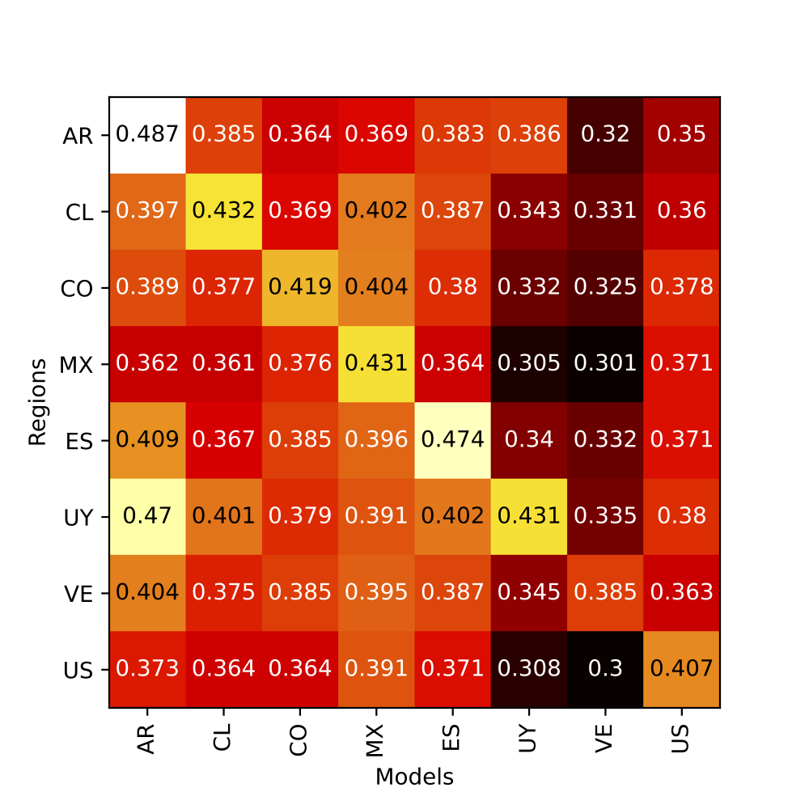

*Accuracy* en predicción de Emoji-15 - *tuneado*

| cc | minrecall | maxrecall | localrank | top5 |
| --- | --- | --- | --- | --- |
| AR | 0.4777 | 0.49 | 3 | UY,PY,AR,PE,CO |
| CL | 0.4257 | 0.4494 | 1 | CL,US,MX,AR,ES |
| CO | 0.4247 | 0.4365 | 2 | US,CO,VE,EC,GT |
| ES | 0.4754 | 0.4855 | 1 | ES,AR,MX,US,VE |
| MX | 0.4233 | 0.4335 | 1 | MX,GT,CR,US,CO |
| US | 0.4041 | 0.4244 | 1 | US,MX,CO,ES,CL |
| UY | 0.4351 | 0.4572 | 1 | UY,US,CO,CL,VE |
| VE | 0.3848 | 0.4338 | 4 | MX,CO,ES,VE,US |

Con word-embeddings

- Se *tuneó* el modelo BILMA para predecir emoticones añadiendo dos capas lineales a los embeddings de inicio, por lo que se puede ver que se predice independiente de la posición.
- *Tuneado* con 90%-10% del training set de la región hasta que el *accuracy* converge.
- Se evaluó con test regional.
- Observe que es una matriz de modelos pre-entrenados y *tuneos*.
- Los resultados en general son muy similares a los modelos de fastText, pero, los modelos BILMA pueden hacer más cosas…

## Usando BILMA para completar frases (mediante máscaras)

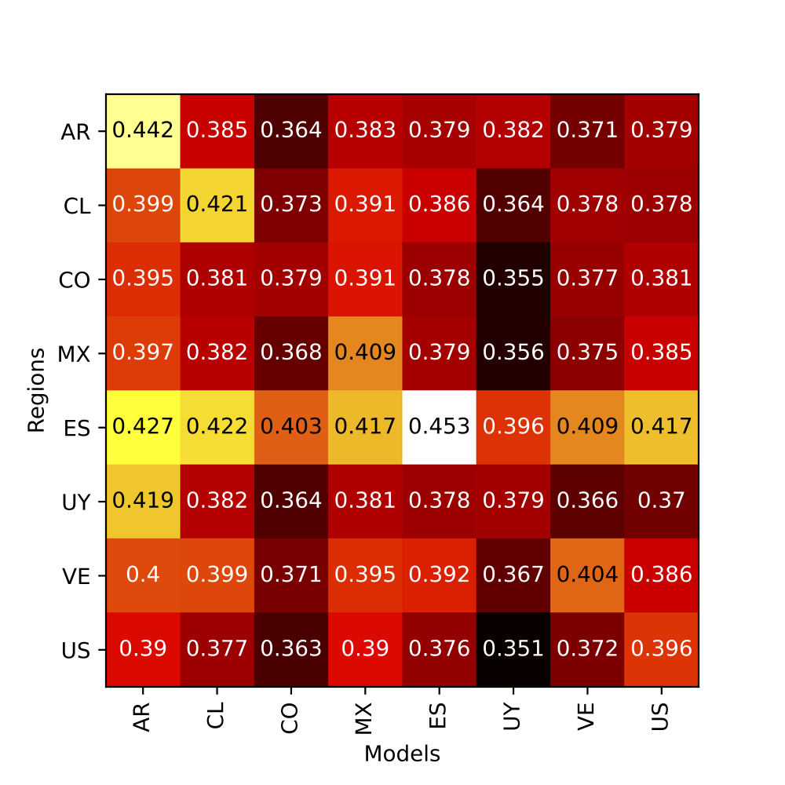

*Accuracy* en la tarea MLM para el test

MLM regional

# Conclusiones y trabajo a futuro

- Recursos generados
- Importancia
- Beneficios de los recursos regionalizados

## Trabajo a futuro

- Aplicaciones y medir impacto.
- Modelos robustos para identificación de regiones.
- Reducir recursos computacionales.
  - Uso de un solo modelo con diferentes niveles de abstracción.
  - Creación de modelos menos costoso.
- Enriquecer los corpus más pequeños.
- Otros lenguajes (inglés, ruso, árabe, etc… o regionales con pocos datos).
- ¿Se puede usar Hausdorff u otras distancias para nubes de puntos para la comparación de regiones?.

## ¿Preguntas?

¡Gracias por su atención!

**Modelos regionales del Español:**

- https://ingeotec.github.io/regional-spanish-models/
- https://github.com/INGEOTEC/regional-spanish-models/

**INGEOTEC:**

- https://github.com/INGEOTEC/
- https://ingeotec.github.io/

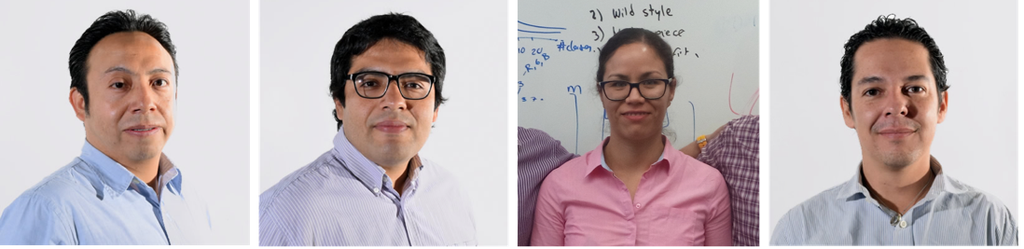